# Additional Checks on High Sparsity Data

Anthony Duncan

```r
library(tidyverse)
library(vegan)
library(glue)
library(ggpubr)
library(patchwork)
library(LorDist)
```

In our evaluations, both LorDist and mean Bray-Curtis dissimilarity continue to function to higher level of sparsity than in the Qi et al. benchmarks.

Here we check using some examples that our sparsification procedure seems to have worked as expected, and visualise LorDist and Bray-Curtis dissimilarities to see what drives this unexpected effect.

## Check sparsification

As a first check, load a source matrix and all it’s levels of sparsity, and ensure non-zero entries match.

```r
sparses <- seq(0, 0.7, 0.1) |>
    as.character()
mat_path <- glue("data/simulated_new/sparsity_{sparses}/1.tsv")
mats <- mat_path |> map(read.table)

compare_mats <- function(a, b) {
    return(
        all((b == 0) |
        (a == b))
    )
}
mat_wrong <- read.table("data/simulated_new/sparsity_0.1/2.tsv")

# Ensure this function works as intended
stopifnot(compare_mats(mats[[1]], mats[[1]]))
stopifnot(compare_mats(mats[[1]], mats[[2]]))
stopifnot(!compare_mats(mats[[2]], mat_wrong))

# Check all sparsified matrices are equal to source
mats[1:length(mats)] |>
    map(\(x) compare_mats(mats[[1]], x)) |>
    unlist() |>
    all()
```

```
## [1] TRUE
```

The sparsification appears to have been done correctly.

We should try plotting the taxa for the maximum level of sparsity and see if the functions are still evident.

```r
# Load metadata to link samples to subjects
sample_md <- read_delim("data/simulated_new/sample_metadata.tsv") |>
  mutate(Phenotype = Label)
```

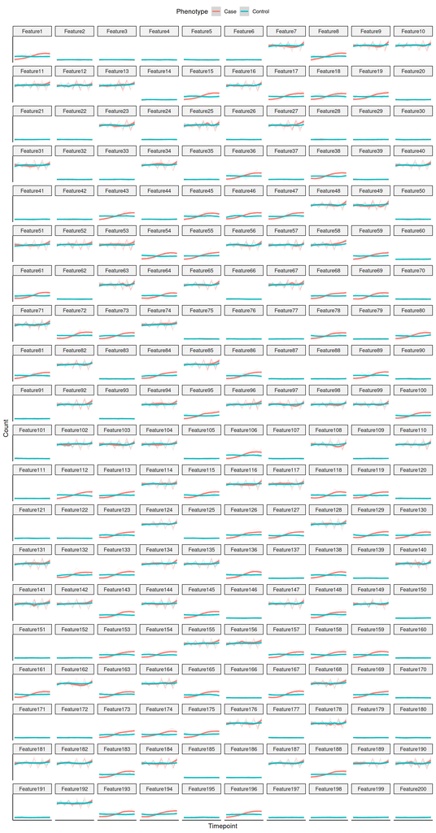

```r
plt_taxa <- mats[[8]] |>
    rownames_to_column("FeatureID") |>
    pivot_longer(-FeatureID, names_to="SampleID") |>
    left_join(sample_md, join_by(SampleID == SampleID)) |>
    mutate(
      value = ifelse(value == 0, NA, value),
      FeatureID = fct_relevel(
        FeatureID, glue("Feature{i}", i=seq(1:200))
      )
    ) |>
    ggplot(
        aes(x = Timepoint, y = value)
    ) +
    geom_line(
        aes(group = SubjectID, color = Phenotype), linewidth=0.1, alpha=0.5
    ) +
    geom_smooth(
        aes(color = Phenotype)
    ) +
    facet_wrap(~FeatureID, ncol = 10) +
    theme_pubr() +
    ylab("Count") +
    theme(
        axis.ticks = element_blank(),
        axis.text = element_blank()
    )

ggsave("results/simulated/check_sparse_taxa.png", dpi=300, width=11, height=21)
plt_taxa
```

Functions are still visually apparent in the 70% sparsity matrix. The fitted line doesn’t capture the periodic taxa very well, but they are visible in the individual traces.

We can also check that it is about 70% sparse.

```r
sum(mats[[8]] == 0) / (dim(mats[[8]])[[1]] * dim(mats[[8]])[[2]])
```

```
## [1] 0.701405
```

## Is this also what the package simulated data looks like?

There is some sample data provided with the LorDist package. Does this sparsified data look similar to what we have simulated?

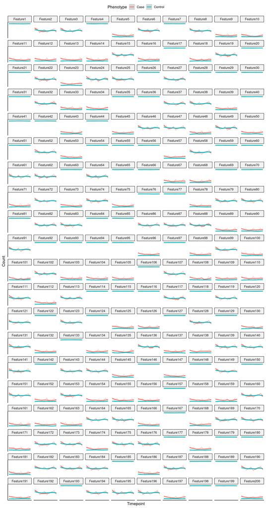

```r
load("data/source/simdata.RData")
ld_sim <- SimData.mat
ld_meta <- SimSample_information |>
    mutate(Phenotype = ifelse(Label == 1, "Case", "Control"))
plt_ld_taxa <- ld_sim |>
    rownames_to_column("FeatureID") |>
    pivot_longer(-FeatureID, names_to="SampleID") |>
    left_join(ld_meta, join_by(SampleID == SampleID)) |>
    mutate(
      value = ifelse(value == 0, NA, value),
      FeatureID = fct_relevel(
        FeatureID, glue("Feature{i}", i=seq(1:200))
      )
    ) |>
    ggplot(
        aes(x = Timepoint, y = value)
    ) +
    geom_line(
        aes(group = SubjectID, color = Phenotype), linewidth=0.1, alpha=0.7
    ) +
    geom_smooth(
        aes(color = Phenotype)
    ) +
    facet_wrap(~FeatureID, ncol = 10) +
    theme_pubr() +
    ylab("Count") +
    theme(
        axis.ticks = element_blank(),
        axis.text = element_blank()
    )

ggsave(
  "results/simulated/check_lordist_taxa.png",
  dpi = 300,
  width = 11,
  height = 21
)
plt_ld_taxa
```

The counts in the provided simulated data do not appear to resemble the proposed generating function closely. None of the plots clearly resemble taxon 3, which is static in control and sigmoid in case. Some such as `Feature10` are similar, but have a sine-like wave with constant amplitude in case, rather than a sigmoid pattern. For taxon 2, the amplitude is less distinctly increasing over `t`, and is quite similar between case and control.

However, it is unclear whether this data from the repository was generated using the simulation method described, so perhaps it is just an alternative, similar set of example data.

## How simple is it to distinguish phenotype?

We will look at how well a simple PCoA on mean B-C dissimilarity separates the two phenotypes in a high sparsity matrices, and compare this to LorDist. This repeats the procedure implemented in `03b_bc_benchmark.R` and `02_lordist_benchmark`, wrapped to a few functions.

```r
remove_empty_samples <- function(mat, sample_metadata) {
  #' Remove any completely empty samples from the abundance and metadata matrix
  #' This is more likely to happen at very high levels of sparsity
  empty_samples <- (mat |> colSums()) > 0
  if(sum(!empty_samples) > 0) {
    log_warn("Empty samples dues to sparsity: {sum(!empty_samples)}")
    log_warn("These samples are dropped from both the abundance and metadata")
    mat <- mat[, empty_samples]
    filt_md <- sample_metadata |>
        filter(SampleID %in% colnames(mat))
    return(list(matrix = mat, metadata = filt_md))
  }
  return(list(matrix = mat, metadata = sample_metadata))
}

make_subject_md <- function(sample_metadata) {
  #' Reduce sample metadata to one row per subject
  subject_md <- sample_md |>
    group_by(SubjectID) |>
    slice_head(n = 1) |>
    column_to_rownames("SubjectID")
  return(subject_md)
}

get_dist_meanbc <- function(mat, sample_metadata) {
  # Get subject rather thank sample metadata
  subject_md <- make_subject_md(sample_metadata)
  # Drop any completely empty samples
  drop_z <- remove_empty_samples(mat, sample_metadata)
  mat <- drop_z$matrix
  sample_metadata <- drop_z$metadata

  # Get per-sample Bray-Curtis
  dist <- vegdist(mat |> t(), method = "bray")

  # Calculate the average between subject Bray-Curtis
  dist_df <- dist |>
    as.matrix() |>
    as.data.frame() |>
    rownames_to_column("id_a") |>
    pivot_longer(
      !id_a,
      names_to = "id_b",
      values_to = "distance"
    ) |>
    dplyr::left_join(
      sample_md |> select(SampleID, SubjectID),
      join_by(id_a == SampleID)
    ) |>
    rename(group_a = SubjectID) |>
    dplyr::left_join(
      sample_md |> select(SampleID, SubjectID),
      join_by(id_b == SampleID)
    ) |>
    rename(group_b = SubjectID)

  # Easiest way to group these is to make this complete
  # Inelegant but achieves the goal
  dist_df2 <- dist_df
  dist_df2$group_b <- dist_df$group_a
  dist_df2$group_a <- dist_df$group_b
  dist_df2$id_a <- dist_df$id_b
  dist_df2$id_b <- dist_df$id_a

  dist_df <- bind_rows(dist_df, dist_df2)

  # Turn back into a distance matrix
  subject_dist <- dist_df |>
    group_by(group_a, group_b) |>
    summarise(distance = mean(distance)) |>
    pivot_wider(names_from = group_a, values_from = distance) |>
    column_to_rownames("group_b") |>
    as.matrix() |>
    as.dist()

  return(subject_dist)
}

get_dist_lordist <- function(mat, sample_metadata) {
  # Drop any completely empty samples
  drop_z <- remove_empty_samples(mat, sample_metadata)
  mat <- drop_z$matrix
  sample_metadata <- drop_z$metadata

  ldist <- LorDist(
    mat,
    sample_metadata |> as.data.frame(),
    SampleID = "SampleID",
    SubjectID = "SubjectID",
    Timepoint = "Timepoint"
  )

  return(ldist)
}

plot_pcoa <- function(dmat, sample_metadata, k = 20, ax1 = "V1", ax2 = "V2") {
  #' Plot two axes of PCoA, and boxplots showing separation of phenotype
  #' on different axes

  subject_md <- make_subject_md(sample_metadata)

  pcoa <- cmdscale(dmat, k = k)
  pcoa_df <- pcoa |>
      as.data.frame() |>
      rownames_to_column("SubjectID") |>
      left_join(subject_md |> rownames_to_column("SubjectID"))

  # Scatter plot
  plt_pcoa_bc <- pcoa_df |>
      ggplot(
          aes(x=!!sym(ax1), y=!!sym(ax2), color=Label, shape=Label)
      ) +
      geom_point() +
      xlab(gsub("V", "PC", ax1)) +
      ylab(gsub("V", "PC", ax2)) +
      theme_pubr()

  # Box plot
  pcoa_df_long <- pcoa |>
    as.data.frame() |>
    rownames_to_column("SubjectID") |>
    pivot_longer(-SubjectID) |>
    left_join(subject_md |> rownames_to_column("SubjectID")) |>
    mutate(name = fct_relevel(name, glue("V{i}", i=1:k)))
  plt_box <- pcoa_df_long |>
    ggplot(
      aes(x=Phenotype, y=value, fill=Phenotype)
    ) +
    geom_boxplot() +
    facet_wrap(~name) +
    scale_y_continuous(expand = expansion(mult=c(0.05, 0.1))) +
    stat_compare_means()
  return(list(
    scatter = plt_pcoa_bc,
    box = plt_box
  ))
}

combine_pcoa_plots <- function(
    ld, bc, sparsity
) {
  plt_combined <- (
    bc + ggtitle("Mean B-C Dissimilarities")
  ) + (
    ld + ggtitle("LorDist Distances")
  ) +
    plot_annotation(
      title = glue("PCoA at {sparsity}% Sparsity"),
      tag_levels = "A"
    ) +
    plot_layout(guides = 'collect') &
    theme(legend.position = "top")
  return(plt_combined)
}
```

### 70% Sparsity

```r
mat <- mats[[8]]

ldist <- get_dist_lordist(mat, sample_md)
bcdist <- get_dist_meanbc(mat, sample_md)
```

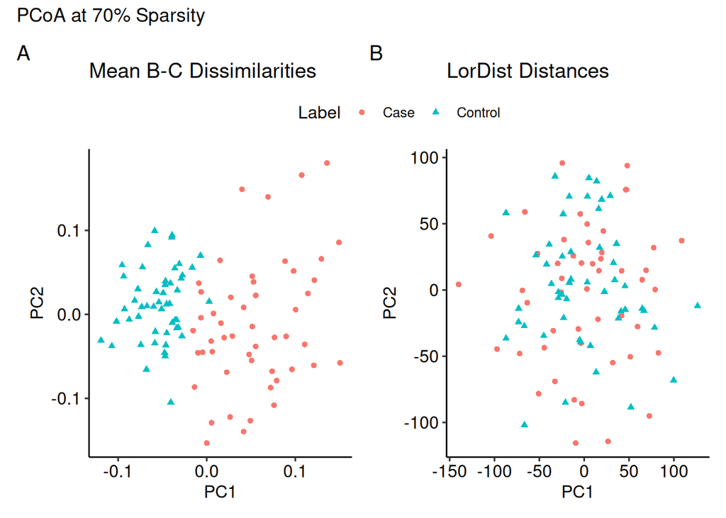

```r
plt_ldist <- plot_pcoa(ldist, sample_metdata, k = 20)
plt_bcdist <- plot_pcoa(bcdist, sample_metdata, k = 20)
combine_pcoa_plots(plt_ldist$scatter, plt_bcdist$scatter, sparsity = 70)
```

Bray-Curtis shows clear separation on axis 1. None evident for LorDist. We can check the box plots to see if there is a better separation available on other axes.

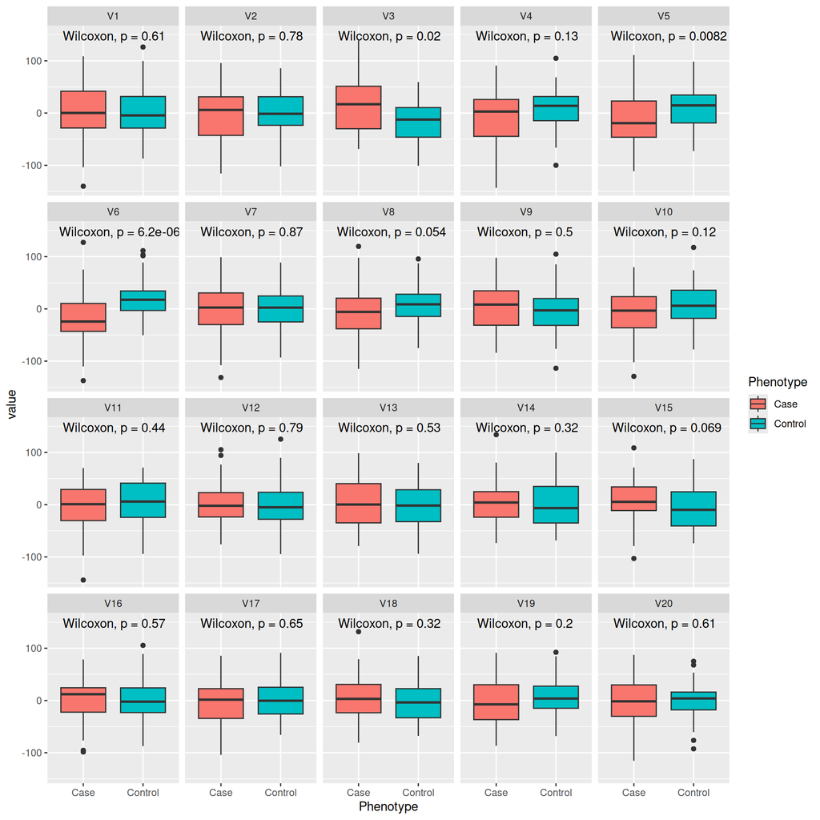

```r
plt_ldist$box
```

There is a significant difference (p < 0.05) on axes 3, 5, and 6, so we should plot these instead. 5 and 6 show the strongest effect so plot those.

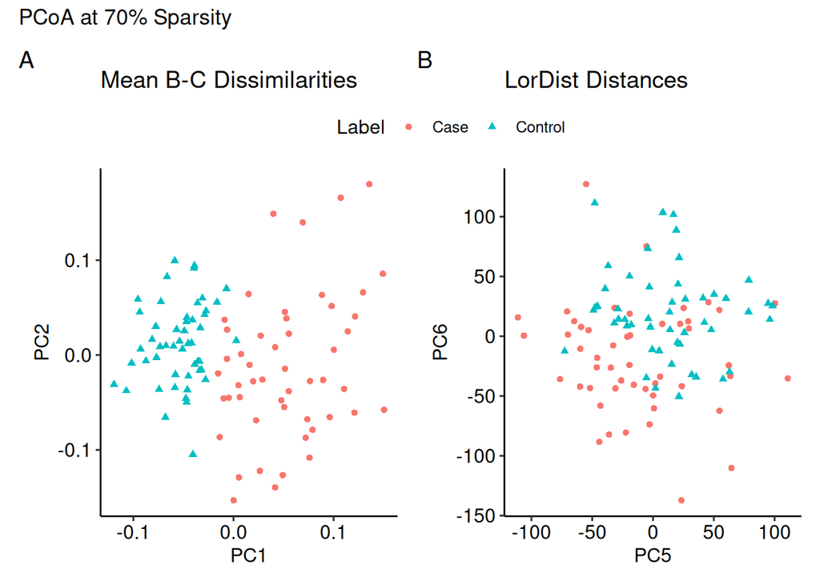

```r
plt_ldist <- plot_pcoa(ldist, sample_metdata, k = 20, ax1 = "V5", ax2 = "V6")
combine_pcoa_plots(plt_ldist$scatter, plt_bcdist$scatter, sparsity = 70)
```

### 80% Sparsity

We have generated some additional data, which were not included in the benchmarks, with 80%, 90% and 95% sparse data.

```r
sample_md <- read_delim("data/simulated_high/sample_metadata.tsv") |>
  mutate(Label = Phenotype)
high_80 <- read.table("data/simulated_high/sparsity_0.8/1.tsv")
high_90 <- read.table("data/simulated_high/sparsity_0.9/1.tsv")
high_95 <- read.table("data/simulated_high/sparsity_0.95/1.tsv")
```

```r
ld_80 <- get_dist_lordist(high_80, sample_md)
bc_80 <- get_dist_meanbc(high_80, sample_md)
```

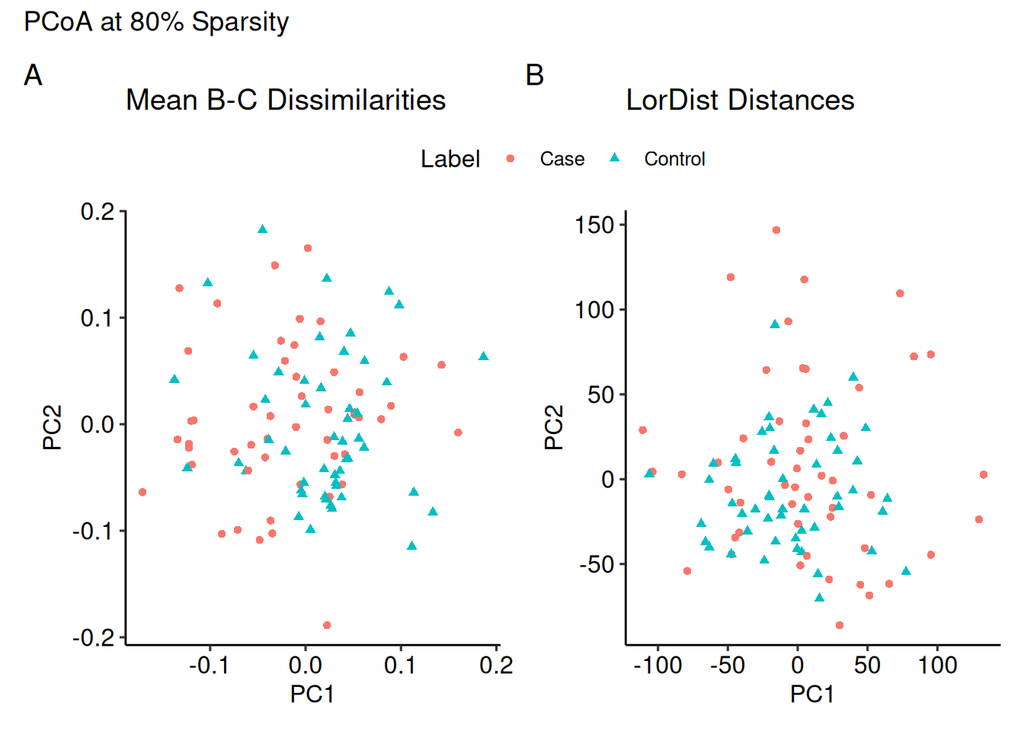

```r
plt_ld_80 <- plot_pcoa(ld_80, sample_metdata, k = 20)
plt_bc_80 <- plot_pcoa(bc_80, sample_metdata, k = 20)
combine_pcoa_plots(plt_ld_80$scatter, plt_bc_80$scatter, sparsity = 80)
```

Poor results at 80% sparsity. We can check whether there’s any evidence of a difference with PERMANOVA

```r
prbc <- adonis2(
  bc_80 ~ Label,
  make_subject_md(sample_md),
  permutations = 1000
)
prld <- adonis2(
  ld_80 ~ Label,
  make_subject_md(sample_md),
  permutations = 1000
)
prbc['Model', 'R2']
```

```
## [1] 0.01266628
```

```r
prld['Model', 'R2']
```

```
## [1] 0.01223502
```

There is some, explaining only 1.2% of variance.